# Activity Recognition

#### Coursera Practical Machine Learning Class

2014-06-20 23:46:06

### Executive Summary

This project analyzed data from six participants, who performed barbell lifts correctly and incorrectly five different ways, and predicted the manner in which an exercise was done for 20 specific test cases.

A combined ensemble model was created using five machine learning methods from the *caret* package (*rf, gbm, treebag, svmPoly, bagFDA*). Each of these approaches (except for svmPoly) separately is an ensemble model.

### Background

Activity research by [Velloso13] looked at recognition of five ways of doing barbell lifts by six subjects. Their goal was to see if data from accelerometer sensors on the belt, forearm, arm and dumbbell could be used to predict qualitative activities.

The five ways of lifting barbells were labeled “A”, “B”,“C”, “D” and “E” in the discussion below.

### Getting and Cleaning Data

Two files were downloaded from the Coursera class assignment web site on June 16, 2014:

- **pml-training.csv**, 19,622 data lines by 160 variables, md5sum 3d8ba9293742dbf0f463c10d3434a0f7
- **pml-testing.csv**, 20 data lines by 160 variables, md5sum ec664556b52a8604adae3dcbd806c404

No code book explaining the variables was available with the data.

```r
rawTrain <- read.csv("pml-training.csv", as.is=TRUE, na.strings=c("", "NA", "#DIV/0!"))
rawTrain$classe <- as.factor(rawTrain$classe)
dim(rawTrain)
```

```
## [1] 19622   160
```

The *rawTrain* data was spit into *training* and *validation* subsets, which will be explained below.

The final test data was never used to develop models, and was only used once with the predictive model on 20 specific cases.

```r
rawFinalTest  <- read.csv("pml-testing.csv",  as.is=TRUE, na.strings=c("", "NA", "#DIV/0!"))
rawFinalTest$problem_id <- as.factor(rawFinalTest$problem_id)
dim(rawFinalTest)
```

```
## [1]  20 160
```

A first look at the data showed a number of variables consisted of almost 98% missing values. These variables were discarded. Missing values consisted of strings “”, “NA” and “#DIV/0!”.

Six text or time variables were thrown out since they did not represent numeric sensor data. Using *user_name* as a factor variable was tempting since the participants were not balanced in the number of samples, but it was thrown out.

```r
### Compute number of NAs per column
NAs <- apply(rawTrain, 2, function(x) { sum(is.na(x)) } )
table(NAs)
```

```
## NAs
##     0 19216 19217 19218 19220 19221 19225 19226 19227 19248 19293 19294
##    60    67     1     1     1     4     1     4     2     2     1     1
## 19296 19299 19300 19301 19622
##     2     1     4     2     6
```

```r
# Keep if no missing values
KEEP <- names(rawTrain)[NAs == 0]

# Remove first six variables that are text or time values.
KEEP[1:6]
```

```
## [1] "X"                    "user_name"            "raw_timestamp_part_1"
## [4] "raw_timestamp_part_2" "cvtd_timestamp"       "new_window"
```

```r
KEEP <- KEEP[-1:-6]   # Remove

LAST <- length(KEEP)
# KEEP[LAST] == "classe" is the classifier

subsetTrain <- rawTrain[,KEEP]
dim(subsetTrain)
```

```
## [1] 19622    54
```

```r
FinalTest  <- rawFinalTest[,c(KEEP[-LAST], "problem_id")]
dim(FinalTest)
```

```
## [1] 20 54
```

The *findCorrelation* function from the *caret* package was used to identify and remove seven variables with correlations of 0.9 or greater. This step was performed to avoid problems with multicollinearity.

```r
cor.matrix <- cor(subsetTrain[,-LAST])

library(caret)
cor.high   <- findCorrelation(cor.matrix, 0.90)

high.corr.remove <- row.names(cor.matrix)[cor.high]
high.corr.remove
```

```
## [1] "accel_belt_z"     "roll_belt"        "accel_belt_y"
## [4] "accel_belt_x"     "gyros_arm_y"      "gyros_forearm_z"
## [7] "gyros_dumbbell_x"
```

```r
subsetTrain <- subsetTrain[,  -cor.high]
FinalTest   <- FinalTest[, -cor.high]

dim(subsetTrain)
```

```
## [1] 19622    47
```

```r
dim(FinalTest)
```

```
## [1] 20 47
```

```r
KEEP <- KEEP[!(KEEP %in% high.corr.remove)]
LAST <- length(KEEP)
```

The *nearZeroVar* function did not identify additional variables for removal. Earlier removal of the variables with many missing values likely took care of this. According to [Kuhn08], a variable may be a near zero-variance predictor if the percentage of unique values is less than 20%, and the ratio of the most frequent to the second most frequent is greater than 20.

After data cleaning, 47 of the original 160 variables were retained for analysis.

### Exploratory Analysis

In the original training set, activity A seems to be a bit over-represented with 5580 observations when activity “D” only had 3216 observations. Participant Pedro only contributed 2610 observations while Adelmo contributed 3892. In the 20 test set, Jeremy was overrepresented with 8 observations while Adelmo and Charles only had 1 each.

Many boxplots showed little separation among the medians of the activities, but a few showed dramatic separation. The boxplots showed some variables may have a number of outliers, and a few showed some skewing, but no outliers were removed and no preprocessing transformations were made.

**Correlation matrix**. The dendrograms along the edges of a heat map of the correlation matrix hinted that the data could be broken into a number of subgroups, perhaps 5.

**Singular Value Decomposition**. The eigenvalues from the SVD analysis suggested five features could account for roughly half of the variance, and 13 features could explain 80%.

```r
svd1 <- svd(scale(subsetTrain[,-LAST]))
cumsum(svd1$d^2/sum(svd1$d^2))[1:15]
```

```
##  [1] 0.1640 0.2890 0.3833 0.4613 0.5250 0.5770 0.6206 0.6626 0.6975 0.7277
## [11] 0.7518 0.7756 0.7974 0.8177 0.8366
```

### How Models Were Built

#### Training, Validation and Test data

The **original training** data was split into **training** and **validation** subsets using the *createDataPartition* function:

```r
inTrain <- createDataPartition(y=subsetTrain$classe, p=0.75, list=FALSE)

training <- subsetTrain[inTrain,]
dim(training)
```

```
## [1] 14718    47
```

```r
Validation  <- subsetTrain[-inTrain,]
dim(Validation)
```

```
## [1] 4904   47
```

The *createDataPartition* function assigned 75% of the original training file to the **training** data and 25% to the **validation** data.

This **training** subset of the original data was used to train all models.

The **validation** subset was NOT used for any training, but rather was used to compute an estimate of the out-of-sample accuracy of the trained models.

*createDataPartition* maintains approximately the same proportions by class:

```r
prop.table(table(training$classe))
```

```
##
##      A      B      C      D      E
## 0.2843 0.1935 0.1744 0.1639 0.1839
```

```r
prop.table(table(Validation$classe))
```

```
##
##      A      B      C      D      E
## 0.2845 0.1935 0.1743 0.1639 0.1837
```

The composite set of five models was applied to the **final test** set of 20 cases exactly once. A voting scheme was used to pick the final classification answer. Each model “cast” one vote and the majority assignment was deemed the predicted class.

#### Preliminary models

Preliminary LDA, QDA and CART (rpart) analyses showed only fair out-of-sample accuracies (68%, 89% and 53%, respectively), so better models using random forests, bagging and boosting were explored.

#### Ensemble Models Explored Using Caret Package

An ensemble of five different ensemble models was used to create a prediction model:

- **Random Forests** (rf) is a classification method based on many decision trees.
- **Stochastic Gradient Boosting** (gbm). Boosting incrementally builds an ensemble with newer models improving on past misclassifications.
- **Bagged CART** (treebag), where bagging is bootstrap aggregating.
- **Support Vector Machines with Polynomial Kernel** (svmPoly).
- **Bagged Flexible Discriminant Analysis** (bagFDA).

An odd number of machine learning methods was used here to avoid “ties” in the final voting.

**The *train* function in the *caret* package took care of cross validation in all of these machine learning methods used to form an overall ensemble model.**

#### Random Forests

**Setup parallel processing**

Let’s try using 6 cores on an i7-4770K 3.50 GHz processor with 32 GB RAM for training [Kuhn13] to speedup the computations:

- *caret* uses *foreach* that parallelizes *for* loops.
- No changes are needed when calling *train*.
- The parallel technology must be registered with *foreach* prior to calling *train*.

The *caret* package made the application of five different machine learning methods quite simple. Each of the models using *caret* followed the same code pattern as shown here for Random Forests:

```r
library(doParallel)
rCluster <- makePSOCKcluster(6)  # Use 6 cores
registerDoParallel(rCluster)

set.seed(219)  # for reproducibility

Sys.time()     # record time for Random Forest training
```

```
## [1] "2014-06-20 23:46:10 CDT"
```

```r
fit.rf <- train(classe ~., data = training, method="rf", prox=TRUE)
fit.rf
```

[output not shown]

```r
Sys.time()
```

```
## [1] "2014-06-21 00:55:01 CDT"
```

The *varImp* function aids in the interpretability of the Random Forest model. *varImp* can be used to characterize the general effect of predictors on a model.

From [Kuhn08]:

*For each tree, the prediction accuracy on the out-of-bag portion of the data is recorded. Then the same is done after permuting each predictor variable. The diference between the two accuracies are then averaged over all trees, and normalized by the standard error. For regression, the MSE is computed on the out-of-bag data for each tree, and then the same computed after permuting a variable. The diferences are averaged and normalized by the standard error.*

```r
varImp(fit.rf)
```

```
## rf variable importance
##
##   only 20 most important variables shown (out of 46)
##
##                      Overall
## num_window            100.00
## pitch_forearm          37.14
## yaw_belt               35.85
## pitch_belt             30.82
## magnet_dumbbell_z      28.87
## magnet_dumbbell_y      25.09
## magnet_belt_y          20.03
## roll_forearm           15.99
## accel_dumbbell_y       11.25
## magnet_dumbbell_x      11.09
## roll_dumbbell          10.43
## magnet_belt_z           9.36
## gyros_belt_z            9.05
## total_accel_belt        8.91
## accel_forearm_x         8.60
## total_accel_dumbbell    8.31
## accel_dumbbell_z        7.93
## accel_forearm_z         7.81
## magnet_belt_x           6.85
## magnet_forearm_z        4.99
```

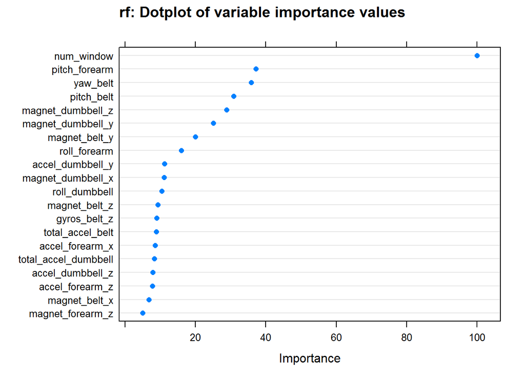

```r
dotPlot(varImp(fit.rf), main="rf: Dotplot of variable importance values")
```

*varImp* shows the 20 most [important variables](http://caret.r-forge.r-project.org/varimp.html) in the Random Forest analysis, including a graphical display.

The reason *num_window* is so important is not clear, since no code book explained the meaning of the variables.

The top 10 variables for other prediction methods studied in the 5-part ensemble:

**Stochastic Gradient Boosting (gbm)**

Top 10 important variables

```
                  Overall
num_window        100.000
yaw_belt           53.059
pitch_forearm      50.845
magnet_belt_y      30.235
magnet_dumbbell_z  28.563
magnet_dumbbell_y  22.422
roll_forearm       20.721
gyros_belt_z       20.017
magnet_belt_z      17.720
pitch_belt         15.224
```

**Bagged CART (treebag)**

Top 10 important variables

```
                     Overall
num_window            100.00
yaw_belt               65.20
pitch_belt             53.45
magnet_dumbbell_y      39.89
magnet_dumbbell_z      38.98
magnet_belt_y          32.20
roll_forearm           30.36
accel_dumbbell_y       30.08
pitch_forearm          29.12
total_accel_belt       28.42
```

**Support Vector Machines with Polynomial Kernel (svmPoly)**

Top 10 important variables

```
                       A     B     C      D     E
pitch_forearm     100.00 63.22 70.98 100.00 68.16
roll_dumbbell      53.29 61.67 85.50  85.50 58.83
accel_forearm_x    81.57 48.75 63.17  81.57 45.31
magnet_arm_x       78.75 52.87 55.06  78.75 65.20
magnet_arm_y       77.07 39.94 53.67  77.07 67.06
accel_arm_x        73.33 51.60 47.09  73.33 60.64
pitch_dumbbell     51.96 71.64 71.64  62.28 47.20
magnet_forearm_x   71.58 49.96 38.90  71.58 41.14
magnet_belt_y      68.35 60.28 63.28  63.42 68.35
magnet_dumbbell_x  64.71 64.87 64.87  48.77 52.16
```

**Bagged Flexible Discriminant Analysis (bagFDA)**

Top 10 important variables

```
                  Overall
roll_forearm       100.00
magnet_belt_z       96.90
magnet_dumbbell_y   92.25
yaw_belt            87.35
magnet_dumbbell_z   83.04
num_window          79.03
magnet_arm_y        74.40
magnet_arm_z        71.42
magnet_belt_y       68.47
pitch_belt          66.12
```

The **validation** data was used to determine the out-of-sample error since it was not used in modeling fitting.

The “confusion matrix” below shows the predicted classifications on the validation data.

```r
OutOfSampleEstimate  <- predict(fit.rf, newdata=Validation)
confusionMatrix(Validation$classe, OutOfSampleEstimate)
```

```
## Confusion Matrix and Statistics
##
##           Reference
## Prediction    A    B    C    D    E
##          A 1395    0    0    0    0
##          B    0  947    2    0    0
##          C    0    0  855    0    0
##          D    0    0    3  801    0
##          E    0    0    0    2  899
##
## Overall Statistics
##
##                Accuracy : 0.999
##                  95% CI : (0.997, 0.999)
##     No Information Rate : 0.284
##     P-Value [Acc > NIR] : <2e-16
##
##                   Kappa : 0.998
##  Mcnemar's Test P-Value : NA
##
## Statistics by Class:
##
##                      Class: A Class: B Class: C Class: D Class: E
## Sensitivity             1.000    1.000    0.994    0.998    1.000
## Specificity             1.000    0.999    1.000    0.999    1.000
## Pos Pred Value          1.000    0.998    1.000    0.996    0.998
## Neg Pred Value          1.000    1.000    0.999    1.000    1.000
## Prevalence              0.284    0.193    0.175    0.164    0.183
## Detection Rate          0.284    0.193    0.174    0.163    0.183
## Detection Prevalence    0.284    0.194    0.174    0.164    0.184
## Balanced Accuracy       1.000    1.000    0.997    0.998    1.000
```

The main diagonal in the confusion matrix shows most predictions were correct, but some off diagonal terms show the prediction was not perfect. The **Accuracy** above, along with its 95% confidence interval, show the predicted out-of-sample accuracy.

The out of sample **error estimate** would be **100% - Accuracy**.

### Summary of Cross Validation and Out-of-Sample Accuracy Estimates

**Stochastic Gradient Boosting** (gbm): 99.2% accuracy (95% CI: 98.9% to 99.4%)

**Bagged CART** (treebag): 99.4% accuracy (99.1% to 99.6%)

**SVM with Polynomical Kernel** (svmPoly): 99.51% (95% CI: 99.3% to 99.7%)

**Bagged Flexible Discriminant Analysis** (bagFDA): 86.7% (95% CI: 85.7% to 87.7%)

Full disclosure: Except for the Random Forest processing, other models were evaluated outside this .Rmd document. Details of the runs were captured in .txt files using the *sink()* statement.

### Results on 20 Specific Test Cases

After evaluating out-of-sample accuracy, the prediction model was applied to the test set of 20 cases.

Each of the five models gave a separate list of 20 predictions. Shown below are the predictions from the Random Forest model:

```r
final.rf <- predict(fit.rf, newdata=FinalTest)
final.rf
```

```
##  [1] B A B A A E D B A A B C B A E E A B B B
## Levels: A B C D E
```

Here is a summary of the assigned classifications by each of the five models (in order from 1 to 20 from left to right):

```
 [1] B A B A A E D B A A B C B A E E A B B B  rf (4 hours, 43 minutes)
 [1] B A B A A E D D A A B C B A E E A B B B  gbm  (23.5 minutes)
 [1] B A B A A E D B A A B C B A E E A B B B  treebag (18.5 minutes)
 [1] B A B A A E D B A A B C B A E E A B B B  svmPoly (7 hours 25 minutes)
 [1] C A B A A C D D A A C C B A E E A B B B  bagFDA (13 hours, 24 minutes)
```

Elapsed analysis running times are shown to the right of the method names above for processing on a 3.5 GHz i7-4770K Windows 7 box with 32 GB memory. In most cases, methods were assigned to different CPUs and were run concurrently. These times were recorded before multiple cores were used.

Consensus vote (majority votes out of 5):

```
 [1] B A B A A E D B A A B C B A E E A B B B
```

2014-06-21 00:55:37

### Conclusions

The combined ensemble method of the five ensemble methods has almost no interpretability. The “most important”" variables were not consistent among the models.

Ironically, the slowest method of the five (bagFDA) was the least accurate.

### References

[Vellosco13] Eduardo Vellsosco, et al. [Qualitative Recognition of Weight Lifting Exercises](http://groupware.les.inf.puc-rio.br/public/papers/2013.Velloso.QAR-WLE.pdf), Proceedings of 4th International Conference in Cooperation with SIGCHI (Augmented Human ’13). *ACM SIGCHI*, 2013.

[Kuhn08] Max Kuhn. [Building Predictive Models in R Using the caret Package](http://www.jstatsoft.org/v28/i05/paper). *Journal of Statistical Software*, Nov. 2008.

[Kuhn13] Max Kuhn. [Predictive Modeling with R and the caret Package](http://www.edii.uclm.es/~useR-2013/Tutorials/kuhn/user_caret_2up.pdf). *useR! 2013*, 2013.

[the caret package](http://caret.r-forge.r-project.org/index.html). Web page visited 20 June 2014.